# Variance and Standard Deviation

March 29, 2020

Section 4.6

### Sample Variance and Sample Standard Deviation

Recall that for a dataset of \( \small n \) observations, \( \small x_1, ..., x_n \), that the *sample mean* is

\[ \bar{x}=\frac{1}{n}\sum\limits_{i=1}^nx_i \]

and the *sample variance* is

\[ s^2 = \frac{1}{n-1}\sum\limits_{i=1}^n(x_i-\bar{x})^2 \]

with \( s = \sqrt{s^2} \) the *sample standard deviation*.

The statistics \( s \) and \( s^2 \) represent **measures of dispersion** of a dataset. Think of \( s \) as the average absolute squared distance of a data value from \( \bar{x} \).

Want to study these concepts in terms of a random variable with a well-defined pmf.

## Variance of a Random Variable

*Definition.*

Let \( \small X \) be a random variable with mean \( \small \mu = E[X] \), such that \( \small \mu < \infty \). Then the **variance of X** is

\[ \sigma^2 = Var[X] = E[(X-\mu)^2] = \sum\limits_{x}(x-\mu)^2P(X=x) \]

and the **standard deviation of X** is \( \small \sigma = \sqrt{\sigma^2} \).

*Notes.*

Can want to write \( \small Var[X] = V[X] \).

Think of \( \small Var[X] \) as the weighted average squared distance of values of \( \small X \) from the mean \( \small \mu \).

\[ Var[X] \geq 0 \text{ for all random variables } \]

\[ Var[X] = E[(X-\mu)^2] \neq E[|X-\mu|] \neq E[X-\mu] \]

### Describing Distributions

We are starting to develop statistics that allow us to describe different distributions. The textbook gives an excellent example (4.22) of four distribution where each has \( E[X] = 4 \) but none have the same variance.

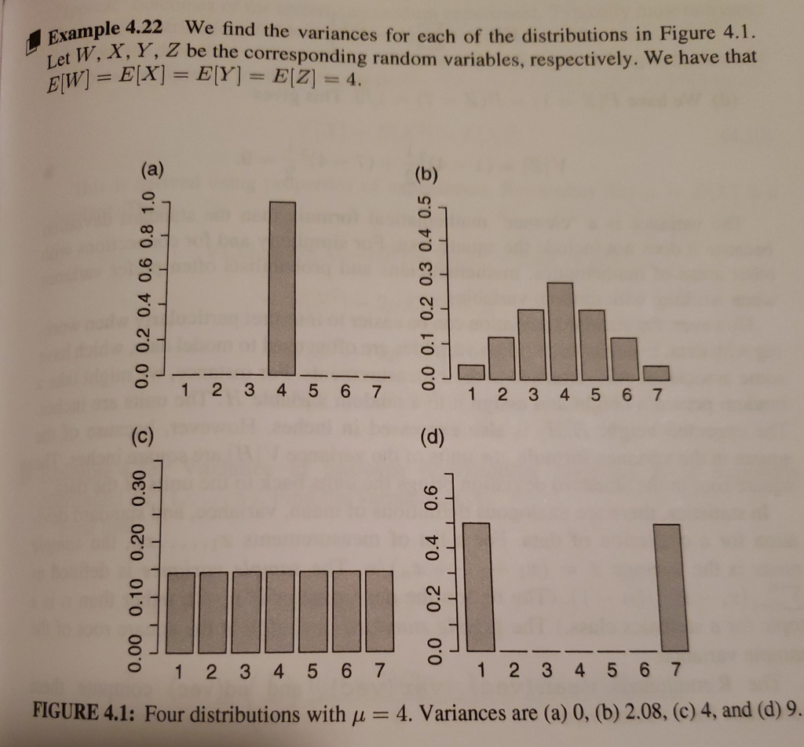

## Working with Variance

*Result 1.*

\[ \begin{aligned} Var[X] = E[X^2]-E[X]^2 = E[X^2] - \mu^2 \end{aligned} \]

*Proof.*

\[ \begin{aligned} Var[X] &= E[(X-\mu)^2] \\ &= E[X^2 - 2X\mu + \mu^2] \\ &= E[X^2] - 2\mu E[X] + \mu^2 \quad &\#\text{Linear Combination} \\ &= E[X^2] - 2\mu^2 + \mu^2 \quad &\#E[X] = \mu \\ &= E[X^2] - \mu^2 \end{aligned} \]

### Example 1

Suppose \( \small X \) is a random variable with \( \small p(x) = \frac{1}{6}1_{\{1,2,...,6\}}(x) \).

Find \( E[X] \) and \( Var[X] \).

To find \( E[X] \), we apply the definition.

\[ E[X] = \sum\limits_{x=1}^6\frac{x}{6} = \frac{21}{6} = \frac{7}{2} = \mu \]

For finding the variance, it is often easier to find \( E[X^2] \) and apply *Result 1*.

\[ E[X^2] = \sum\limits_{x=1}^6\frac{x^2}{6} = \frac{91}{6} \]

*Note.* This result uses that \( \sum\limits_{x=1}^{k}x^2 = \frac{k(k+1)(2k+1)}{6} \)

We can then apply *Result 1* to show that

\[ \sigma^2 = Var[X] = E[X^2] - E[X]^2 = \frac{91}{6} - \left(\frac{7}{2}\right)^2 = \frac{35}{12} \]

We can also state that \( \sigma = \sqrt{\sigma^2} = \sqrt{\frac{35}{12}} \approx 1.7078 \).

## Variance and Independent Random Variables

*Result 2.*

Let \( X \) and \( Y \) be independent random variables and set \( Z = aX + bY + c \) for any constants \( a,b,c \). Then,

\[ \sigma^2_Z = Var[Z] = a^2Var[X] + b^2Var[Y] \]

or

\[ \sigma^2_Z = a^2\sigma^2_X + b^2\sigma^2_Y \]

*Important Notes/Cases when X and Y independent random variables.*

\( Var[X + Y] = Var[X] + Var[Y] \)

\( Var[X - Y] = Var[X] + Var[Y] \)

\( Var[aX] = a^2Var[X] \)

\( Var[a] = 0 \) for any constant \( a \).

## Binomial Variance

*Result 3.*

Suppose \( \small X \sim Binom(n,p) \), then \( \small \sigma^2_X = np(1-p) \).

*Proof.*

We use that \( X \) can be written as the sum of indpendent Bernoulli trials, such that if \( X_1, ..., X_n \stackrel{iid}\sim Ber(p) \), then, \( X = \sum\limits_{i=1}^nX_i \). Now apply *Result 2.*,

\[ \begin{aligned} Var[X] &= Var[\sum\limits_{i=1}^nX_i] \\ &= \sum\limits_{i=1}^nVar[X_i] &\#\text{Independent} \\ &= nVar[X_1] &\#\text{Identical} \end{aligned} \]

Where \( Var[X_1] \) represents the variance of a \( Bernoulli(p) \) random variable.

## Binomial Variance

*Proof continued.*

What is \( Var[X_1] \)?

Recall that \( E[X_1] = p \) from earlier results of Bernoulli random variables.

We want to use *Result 1* again here, so we must find

\[ E[X_1^2] = \sum\limits_{x=0}^1x_1^2P(X_1=x_1) = (1)^2p + (0)^2(1-p) = p \]

and through application of *Result 1* we have that

\[ Var[X_1] = p - p^2 = p(1-p) \]

Returning to our result for a Binomial random variable, we can now state that

\[ Var[X] = nVar[X_1] = np(1-p) \]

when \( X \sim Binom(n,p) \).

### Example 2

Consider \( Y \) a random variable with \( p_Y(y) = \frac{1}{2}1_{\{1,6\}}(y) \).

Find \( E[Y] \).

\[ E[Y] = 1\frac{1}{2} + 6\frac{1}{2} = \frac{7}{2} \]

Find \( E[Y^2] \).

\[ E[Y^2] = 1^2\frac{1}{2} + 6^2\frac{1}{2} = \frac{37}{2} \]

Find \( \sigma^2_Y = Var[Y] \).

\[ \sigma^2_Y = E[Y^2] - E[Y]^2 = \frac{37}{2} - \left(\frac{7}{2}\right)^2 = \frac{74}{4} - \frac{49}{4} = \frac{25}{4} = 6.25 \]

## Distribution Results

(1) If \( X \sim Unif(\{1,...,n\}) \), then \( Var[X] = \frac{n^2-1}{12} \)

*Note.* What if \( \small X \sim Unif(\{a,...,b\}) \)?

(2) If \( X \sim Ber(p) \), then \( Var[X] = p(1-p) \).

(3) If \( X \sim Pois(\lambda) \), then \( Var[X] = E[X] = \lambda \).

*Can you prove these?*